# hw1-regression

Mohammad Mehdi Zare

2023-04-11

libraries :

```r
Sys.setlocale(locale = 'persian')
```

```
## [1] "LC_COLLATE=Persian_Iran.1256;LC_CTYPE=Persian_Iran.1256;LC_MONETARY=Persian_Iran.1256;LC_NUMERIC=C;LC_TIME=Persian_Iran.1256"
```

```r
library(data.table)
library(ggplot2)
library(patchwork)
library(imager)
library(lemon)
knit_print.data.frame <- lemon_print
```

در این خط دیتا ست را از روی فایل میخوانیم .

```r
d = fread('C:\\Users\\Mehdi\\Documents\\R\\workspace\\iranprovs_mortality_monthly.csv', encoding = 'UTF-8')
head(d)
```

| y | m | prov | sex | age_group | n |
| --- | --- | --- | --- | --- | --- |
| 1389 | 12 | آذربايجان شرقي | زن | 0 | 121 |
| 1389 | 12 | آذربايجان شرقي | زن | 01-04 | 568 |
| 1389 | 12 | آذربايجان شرقي | زن | 05-09 | 331 |
| 1389 | 12 | آذربايجان شرقي | زن | 10-14 | 190 |
| 1389 | 12 | آذربايجان شرقي | زن | 15-19 | 185 |
| 1389 | 12 | آذربايجان شرقي | زن | 20-24 | 251 |

همانطور که مشاهده میکنیم دیتا ست شامل 6 ستون سال و ماه و استان و جنسیت و گروه سنی و تعداد مرگ و میر است . با توجه به صورت سوال و نوع دیتا , تصمیم گرفتم که به تفکیک استان و ماه مدل خطی بر روی 5 سال قبل از کرونا تا زمان کرونا فیت کنم و با توجه به ان مقدار فوت اضافه در سال های کرونایی را تخمین بزنم.

توجه کنید که اگر بخواهیم تفکیک جنسیت و گروه سنی را هم دخیل کنیم, تعداد مدل ها خیلی زیاد و ناکارامد میشود و همچنین با توجه به اینکه دیتا به بخش های زیادی میشکند , تعداد دیتای ترین مدل خیلی کم میشود و احتمالا مدل های خوبی بدست نمیاوریم. همچنین میدانیم که جنسیت تاثیری در مرگ و میر ناشی از کرونا ندارد.از لحاظ گروه سنی , با توجه به اینکه ما دنیال فوت اضافه هستیم , فرض میکنیم که قبل از کرونا تعداد مرگ ومیر در گروه های سنی متفاوت از یک فرم خطی پیروی میکند . پس اگر مدل خطی را مستقل از گروه سنی بزنیم , باز تاثیر خیلی بدی در مدل ما نخواهد داشت.و این به خاطر این است که مرگ و میر ناشی از کرونا , در همه گروه ها افزایش داشته است.

همچنین با توجه به اینکه ما دیتای از سال 1389 را داریم , اگر بخواهیم مدل را روی همه سال های قبل کرونافیت کنیم , تقریبا یک خط افقی میدهد و معیار های دیگری مثل جمعیت و سطح رفاه و حوادث طبیعی و .. را دخیل میکند پس با نگاه کلی به دیتای چند استان , تصمیم گرفتم که 5 سال قبل کرونا را برای اموزش مدل در نظر بگیرم. با توجه به توضیحات بالا ستون های گروه سنی و جنسیت را حذف میکنیم. همچنین برای راحتی کار و مقایسه و نشان دادن تاریخ ها , هر سال را با تقسیم بر 13 ماه هایش جمع میکنیم . با این کار ترتیب ماه ها حفظ میشود و دیگر نیازی به تبدیل تاریخ ها به میلادی نیست.

```r
d$ym_num = d$y + (d$m / 13)
ym_num_covid = 1398 + 10/13
ym_num_start = ym_num_covid - 5
newDataSet = d[, .(n = sum(n)), .(y, m, ym_num, prov), ]
newDataSet=newDataSet[ym_num > ym_num_start]
newDataSet$excess_mortality=0
newDataSet$normal_excess_mortality=0

head(newDataSet)
```

| y | m | ym_num | prov | n | excess_mortality | normal_excess_mortality |
| --- | --- | --- | --- | --- | --- | --- |
| 1393 | 12 | 1393.923 | آذربايجان شرقي | 1928 | 0 | 0 |
| 1393 | 12 | 1393.923 | آذربايجان غربي | 1239 | 0 | 0 |
| 1393 | 12 | 1393.923 | اردبيل | 688 | 0 | 0 |
| 1393 | 12 | 1393.923 | اصفهان | 2048 | 0 | 0 |
| 1393 | 12 | 1393.923 | البرز | 740 | 0 | 0 |
| 1393 | 12 | 1393.923 | ايلام | 275 | 0 | 0 |

در کد بالا مقدار تاریخ 5 سال قبل از کرونا را نشان میدهد که باری اموزش مدل از این سال ها استفاده میکنیم و سال های قبل از ان را کاری نداریم. همچنین مقدار زمان شروع کرونا رابه ما میدهد.

حالا به ازای همه ماه ها و استان ها در سال های مختلف , مدل خطی فیت میکنیم و مقدار فوت را تا قبل کرونا با یک خط مدل میکنیم. و سپس برای هر ماه و استان در سال های بعد کرونا طبق خط بدست امده , یک پیشبینی از تعدد مرگ و میر عادی میکنیم . اگر مرگ و میر ثبت شده از دو برابر سیگما مدل به عللاوه مرگ و میر پیشبینی شده , بیشتر بود, ینی مرگ و میر ناشی از کرونا بوده و تفاضل مقدار پیشبینی شده و ثبت شده را , فوت اضافه مینامیم و در دیتا ست ذخیره میکنیم. همچنین p_value ضرایب را نگاه میکنیم و اگر این مقدار برای یک مدل زیاد بود و شیب ان خط نزدیک شیب افقی نبود ,انرا با خط افقی میانگین جایگزین میکنیم . از انجا که در خط های تقریبا افقی به خاطر فرض صفر این مقدار زیاد میشود, پس مقدار ترشهولد را بالا در نظر گرفتم.

```r
for (i in 1:31) {
  PROV = unique(newDataSet$prov)[i]
  for (j in 1:12) {
    M=j
    dsm = newDataSet[prov == PROV & m == M,]
    dsm2fit = dsm[ym_num < ym_num_covid]

    fit = lm(n ~ ym_num, dsm2fit)
    p_value=summary(fit)$coefficients[,4][2]

    if (p_value>.7& summary(fit)$coefficients[,1][2]>15){
      dsm$n_predicted = mean(dsm2fit$n)
    }else{
      dsm$n_predicted = predict(fit ,dsm)
    }

    sigmaa=summary(fit)$sigma
    dsm$excess_mortality=dsm$n-dsm$n_predicted

    dsm[dsm$n_predicted+2*sigmaa > dsm$n]$excess_mortality  =  0
    newDataSet[prov == PROV & m == M & ym_num > ym_num_covid]$excess_mortality  =  dsm[ym_num > ym_num_covid]$excess_mortalit

    # in this lines i plot models of one province
      if(j==10 | j==8 | j==9){
        dsm=rbind(dsm,dsm[nrow(dsm),])
      }

      dsm$ymin = dsm$n_predicted-2*sigmaa
      dsm$ymax = dsm$n_predicted+2*sigmaa

      if(j==1){
        p<-ggplot(dsm,aes(x=ym_num, y=n_predicted))+
                    geom_ribbon(aes(ymin =ymin, ymax = ymax), fill = "grey70")+
                    geom_line(method = 'lm')+
                    geom_point(aes(ym_num, n), size = 1)+
                    scale_x_continuous(breaks = 1393:1401)+
                    geom_vline(xintercept = 1398 + 10/13, linetype = 'dashed')+
                    ggtitle(label = PROV, subtitle = paste('month: ', M))+xlab("year")+ylab("death")
        }else{

        p=p+ ggplot(dsm,aes(x=ym_num, y=n_predicted))+
                    geom_ribbon(aes(ymin = ymin, ymax = ymax), fill = "grey70")+
                    geom_line(method = 'lm')+
                    geom_point(aes(ym_num, n), size = 1)+
                    scale_x_continuous(breaks = 1393:1401)+
                    geom_vline(xintercept = 1398 + 10/13, linetype = 'dashed')+
                    ggtitle(label = PROV, subtitle = paste('month: ', M))+xlab("year")+ylab("death")    }
  }
  # ggsave(paste(PROV,".png"),width = 20, height = 20)
}
```

[figure not shown]

حالا و از روی مدل ها به جواب سوالات تمرین میپردازیم. سوال اول< در سوال اول گفته شده بود که نقشه حراتی کرونا را نشان دهیم :

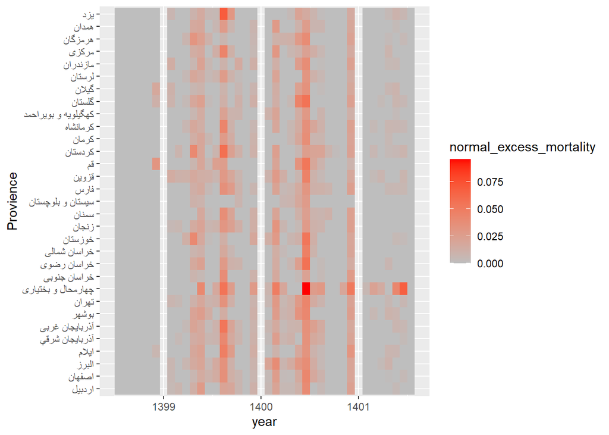

```r
for (i in 1:31) {
  PROV = unique(newDataSet$prov)[i]

newDataSet[ym_num>=ym_num_covid & prov==PROV ]$normal_excess_mortality=  newDataSet[ym_num>=ym_num_covid & prov==PROV]$excess_mortality /(sum( newDataSet[ym_num>=ym_num_covid & prov==PROV]$n)-sum( newDataSet[ym_num>=ym_num_covid & prov==PROV]$excess_mortality))
}

g<-ggplot(newDataSet[ym_num>1398.5], aes(x =  newDataSet[ym_num>1398.5]$ym_num,
                  y = newDataSet[ym_num>1398.5]$prov,
                  fill = normal_excess_mortality))+xlab("year")+ylab("Provience")+geom_tile()+scale_fill_gradient(high = "red", low = "gray")
```

<سوال دوم<

تعداد فوت اضافه در کشور برابر :

```r
 print(round(sum(newDataSet$excess_mortality)))
```

```
## [1] 270259
```

<سوال سوم<

تعداد فوت اضافه در کشور به تفکیک استان ها عبارت است از :

```r
newDataSet= newDataSet[ym_num>=ym_num_covid]
provds = newDataSet[, .(excess_mortality =round( sum(excess_mortality)), n= sum(n)), .( prov)]
provds$normal_excess_mortality= provds$excess_mortality/((provds$n-provds$excess_mortality))
provds[order(excess_mortality)]
```

| prov | excess_mortality | n | normal_excess_mortality |
| --- | --- | --- | --- |
| کهگيلويه و بويراحمد | 1327 | 9686 | 0.1587510 |
| خراسان جنوبي | 1552 | 12975 | 0.1358662 |
| ايلام | 1785 | 8717 | 0.2575014 |
| خراسان شمالي | 1915 | 15920 | 0.1367369 |
| سمنان | 2020 | 12238 | 0.1976904 |
| بوشهر | 3140 | 15507 | 0.2539015 |
| يزد | 3260 | 17387 | 0.2307638 |
| سيستان و بلوچستان | 3393 | 42086 | 0.0876903 |
| زنجان | 3881 | 18806 | 0.2600335 |
| هرمزگان | 4005 | 22308 | 0.2188166 |
| لرستان | 4557 | 30669 | 0.1745175 |
| قم | 4617 | 22491 | 0.2583082 |
| اردبيل | 4625 | 24672 | 0.2307078 |
| مرکزي | 4882 | 27364 | 0.2171515 |
| قزوين | 5143 | 22639 | 0.2939529 |
| چهارمحال و بختياري | 5546 | 14430 | 0.6242683 |
| همدان | 5814 | 36866 | 0.1872343 |
| کردستان | 6815 | 27117 | 0.3356812 |
| گلستان | 6845 | 32883 | 0.2628850 |
| کرمان | 7730 | 47766 | 0.1930762 |
| کرمانشاه | 7742 | 39136 | 0.2466076 |
| گيلان | 8335 | 56102 | 0.1744929 |
| مازندران | 9798 | 59370 | 0.1976519 |
| البرز | 10924 | 44182 | 0.3284623 |
| آذربايجان غربي | 12777 | 56275 | 0.2937376 |
| خوزستان | 15480 | 76076 | 0.2554624 |
| فارس | 16724 | 79652 | 0.2657640 |
| آذربايجان شرقي | 17111 | 82186 | 0.2629428 |
| اصفهان | 18550 | 89242 | 0.2624059 |
| خراسان رضوي | 19667 | 111214 | 0.2148295 |
| تهران | 50299 | 219270 | 0.2976783 |

<سوال چهارم<

در مورد اینکه کدام استان در کنترل بیماری موفق بوده بنده با امتیاز دهی به استان ها بر اساس 3 معیار 1- رتبه چند در تعداد مرگ و میر کرونایی دارد 2- شاهد چند موج کرونا در این استان بوده ایم . 3- نسبت به جمعیت خود در رتبه چندم از مرگ و میر است

با توجه به این معیار ها به هر استان یک عدد نسبت میدهیم که کمینه ان استانی است که در مجموع بهرین عملکرد را در کنترل کرونا داشته است.

دلیل انتخاب این معیار ها این است که در همه جز یکی تاثیر جمعیت حدف شده است . موج های کرونا اگر در استانی کمتر باشه , به معنی است که نوانسته از ورود موجی که در کشور راه افتاده است جلوگیری کند و موج کرونای کمتری را متحمل شود . میعار دیگر رتبه مرک ومیر استان در مرگ و میر کشور است و این به جمعیت بی ربط نیست ولی میدانیم که اگر کرونا در جایی سرایت کمتری داشته باشه , مرگ ومیر کمتری دارد و اگر استانی بتواند جلوی سرایت را بگیرد مرگ و میر کمتری را تجربه میکند . معیار سوم هم که مقایسه نرمال شده مرگ و میر کرونایی هر استان است نسان دادن عملکرد کلی هر استان در کنترل کرونا است.

```r
 provds$percent_excess_mortality=provds$excess_mortality/sum(provds$excess_mortality)
 provds$wave_num=0
 for (PROV in unique(newDataSet$prov)) {
   provData= newDataSet[prov==PROV &ym_num>ym_num_covid ]
   provData=provData[order(ym_num),]
   provds[prov==PROV]$wave_num=length( which(diff(sign(diff(provData$normal_excess_mortality)))==-2)+1)
    }
 provds$point = provds$percent_excess_mortality/max(provds$percent_excess_mortality) + provds$normal_excess_mortality/max( provds$normal_excess_mortality)+
  provds$wave_num/max(provds$wave_num)
 provds$wave_num_rank=rank(-provds$wave_num)
provds[order(point), .(prov, point,wave_num,normal_excess_mortality,percent_excess_mortality)]
```

| prov | point | wave_num | normal_excess_mortality | percent_excess_mortality |
| --- | --- | --- | --- | --- |
| سيستان و بلوچستان | 0.5079255 | 3 | 0.0876903 | 0.0125546 |
| خراسان شمالي | 0.7571077 | 5 | 0.1367369 | 0.0070858 |
| لرستان | 0.8701534 | 5 | 0.1745175 | 0.0168616 |
| خراسان جنوبي | 0.9484962 | 7 | 0.1358662 | 0.0057426 |
| کهگيلويه و بويراحمد | 0.9806816 | 7 | 0.1587510 | 0.0049101 |
| يزد | 1.0344672 | 6 | 0.2307638 | 0.0120625 |
| سمنان | 1.0568351 | 7 | 0.1976904 | 0.0074743 |
| قم | 1.1055685 | 6 | 0.2583082 | 0.0170836 |
| همدان | 1.1155148 | 7 | 0.1872343 | 0.0215127 |
| مرکزي | 1.1449092 | 7 | 0.2171515 | 0.0180642 |
| کرمان | 1.1629650 | 7 | 0.1930762 | 0.0286022 |
| زنجان | 1.1936998 | 7 | 0.2600335 | 0.0143603 |
| هرمزگان | 1.2301407 | 8 | 0.2188166 | 0.0148191 |
| ايلام | 1.2479730 | 8 | 0.2575014 | 0.0066048 |
| بوشهر | 1.2691452 | 8 | 0.2539015 | 0.0116185 |
| کرمانشاه | 1.3489542 | 8 | 0.2466076 | 0.0286466 |
| اردبيل | 1.3615153 | 9 | 0.2307078 | 0.0171132 |
| قزوين | 1.3731244 | 8 | 0.2939529 | 0.0190299 |
| خوزستان | 1.4169785 | 7 | 0.2554624 | 0.0572784 |
| آذربايجان غربي | 1.4245520 | 7 | 0.2937376 | 0.0472769 |
| خراسان رضوي | 1.4351319 | 7 | 0.2148295 | 0.0727709 |
| البرز | 1.4433369 | 7 | 0.3284623 | 0.0404205 |
| گيلان | 1.4452248 | 10 | 0.1744929 | 0.0308408 |
| فارس | 1.4582125 | 7 | 0.2657640 | 0.0618814 |
| مازندران | 1.5114088 | 10 | 0.1976519 | 0.0362541 |
| گلستان | 1.5571952 | 10 | 0.2628850 | 0.0253276 |
| آذربايجان شرقي | 1.6613872 | 9 | 0.2629428 | 0.0633133 |
| کردستان | 1.6732092 | 10 | 0.3356812 | 0.0252166 |
| اصفهان | 1.6891362 | 9 | 0.2624059 | 0.0686379 |
| چهارمحال و بختياري | 2.0102606 | 9 | 0.6242683 | 0.0205211 |
| تهران | 2.3768435 | 9 | 0.2976783 | 0.1861141 |

حالا روش دیگری را امتحان میکنم . در این روش برای هر گروه سنی در هر استان و در ماه های مختلف , فوت اضافه را پیدا میکنم . برای این کار از مدل های دیگر و بیشتری استفاده میکنم . اگر در استانی نرمال شده مرگ ومیر کرونایی گروه 2 که جوان و میانسال است , زیاد تر باشد . به معنی است که کرونا گسترش بیشتری داشته . زیرا اگر فوت اضافه زیادی در پیر ها و بچه ها مشاهده شود نمیتوان شیوع زیاد را فهمید چون که انها مقاومت کمتری نسبت به بیماری دارند و دردصد بیشتری فوت میشوند ولی جوان ها مقاومت بیشتری دارند و درصد کمتری فوت میشوند . بنابراین من به نرمال شده مرگ و میر گروه 2 ضریب 3 دادم . و سپس این مقدار نرمال شده را برای هر استان در گروه های مختلف جمع کردم . استانی که مقدار بالا برای ان کمینه شود بهترین عملکرد را داشته است .

```r
for( i in 0:20){
  if(i<8){
  d[as.numeric(rownames(d))%%21==i,]$age_group=1
  }else if(i<16){
      d[as.numeric(rownames(d))%%21==i]$age_group=2
  }else{
      d[as.numeric(rownames(d))%%21==i]$age_group=3
  }
}

newDataSet1 = d[, .(n = sum(n)), .(y, m, ym_num, prov,age_group), ]
newDataSet1=newDataSet1[ym_num > ym_num_start]
newDataSet1$excess_mortality=0
newDataSet1$normal_excess_mortality=0


for (k in 1:3) {
for (i in 1:31) {
  PROV = unique(newDataSet1$prov)[i]
  for (j in 1:12) {
    M=j
    dsm = newDataSet1[prov == PROV & m == M & age_group==k,]
    dsm2fit = dsm[ym_num < ym_num_covid]

    fit = lm(n ~ ym_num, dsm2fit)
    p_value=summary(fit)$coefficients[,4][2]

    if (p_value>.7& summary(fit)$coefficients[,1][2]>15){
      dsm$n_predicted = mean(dsm2fit$n)
    }else{
      dsm$n_predicted = predict(fit ,dsm)
    }

    sigmaa=summary(fit)$sigma
    dsm$excess_mortality=dsm$n-dsm$n_predicted

    dsm[dsm$n_predicted+2*sigmaa > dsm$n]$excess_mortality  =  0
    newDataSet1[prov == PROV & m == M & ym_num > ym_num_covid & age_group==k]$excess_mortality  =  dsm[ym_num > ym_num_covid]$excess_mortalit
  }
}
}


newDataSet2=newDataSet1[ym_num>=ym_num_start ]
newDataSet2= newDataSet2[, .(n = sum(n), excess_mortality=sum(excess_mortality)), .( prov, age_group), ]
newDataSet2$normal_excess_mortality=0
for (i in 1:3) {
  if (i==2) {
    newDataSet2[age_group==i]$normal_excess_mortality=3*newDataSet2[age_group==i]$excess_mortality / newDataSet2[age_group==i]$n
  }else{
    newDataSet2[age_group==i]$normal_excess_mortality=  newDataSet2[age_group==i]$excess_mortality / newDataSet2[age_group==i]$n
  }
}

newDataSet3= newDataSet2[, .(n = sum(n), excess_mortality=sum(excess_mortality), normal_excess_mortality=sum(normal_excess_mortality)), .( prov), ]
newDataSet3[order(normal_excess_mortality), .(prov,normal_excess_mortality)]
```

| prov | normal_excess_mortality |
| --- | --- |
| سيستان و بلوچستان | 0.2426897 |
| خراسان شمالي | 0.3028725 |
| لرستان | 0.3230921 |
| خراسان جنوبي | 0.3240922 |
| کرمان | 0.3375692 |
| کهگيلويه و بويراحمد | 0.3401055 |
| همدان | 0.3409900 |
| گيلان | 0.3564838 |
| مرکزي | 0.3656037 |
| مازندران | 0.3657056 |
| يزد | 0.3873277 |
| سمنان | 0.3969581 |
| کرمانشاه | 0.3983335 |
| خراسان رضوي | 0.4092087 |
| هرمزگان | 0.4195060 |
| اصفهان | 0.4537577 |
| خوزستان | 0.4542873 |
| زنجان | 0.4668321 |
| فارس | 0.4699236 |
| بوشهر | 0.4799345 |
| گلستان | 0.4924833 |
| آذربايجان شرقي | 0.4927377 |
| قم | 0.4927798 |
| اردبيل | 0.4949514 |
| قزوين | 0.5061566 |
| تهران | 0.5098516 |
| آذربايجان غربي | 0.5163982 |
| ايلام | 0.5400622 |
| کردستان | 0.5454328 |
| البرز | 0.5981594 |
| چهارمحال و بختياري | 0.7475588 |

با توجه به روش اول میبینیم که استان سیستان و بلوچستان طبق امتیازی که به ان نسبت دادیم, بهترین عملکرد را داشته و تفاوت بین استان های بعدی چندان زیاد نیست و خراسان شمال و لرستان در رتبه دوم و سوم بهتین عملکرد ها هستند.

در روش دوم مشابه روش اول استان سیستان و بلوچستان در رتبه اول و خراسان شمالی در رتبه دوم است و لرستان در رتبه سوم قرار میگیرد.